# Análisis Datos Students | Varhulik & Loncarica

Informe de resultados académicos

Análisis exploratorio del dataset Students

Autores/as

Afiliación

Melina Ayelen Varhulik

USAM | Universidad Nacional de San Martin

Maria Trinidad Loncarica

USAM | Universidad Nacional de San Martin

Fecha de publicación

1 de marzo de 2026

Resumen

Este informe presenta el análisis estadístico del dataset Students, incluyendo visualizaciones y modelos.

Palabras clave

educación, estadística, R, análisis

## 0.1 Análisis: *Students Habits Performance*

En el presente trabajo se analiza el conjunto de datos *student_habits_performance.csv*, el cual contiene información detallada sobre los hábitos de estudiantes universitarios y su rendimiento académico.

### 0.1.1 Definición de variables

**Variable dependiente**

- `exam_score`: variable cuantitativa continua que representa el rendimiento académico del estudiante.

**Variables independientes**

- `study_hours_per_day`: cuantitativa continua.
- `social_media_hours`: cuantitativa continua.
- `sleep_hours`: cuantitativa continua.
- `attendance_percentage`: cuantitativa continua.
- `mental_health_rating`: cuantitativa continua.
- `exercise_frequency`: cuantitativa discreta.
- `diet_quality`: cualitativa ordinal.
- `part_time_job`: cualitativa dicotómica.
- `parental_education_level`: cualitativa ordinal.
- `internet_quality`: cualitativa ordinal.
- `gender`: cualitativa nominal.

### 0.1.2 Hipótesis

Los hábitos de vida de los estudiantes, como las horas de estudio, el descanso, el uso de redes sociales y la salud mental, tienen un impacto significativo en su rendimiento académico medido a través de `exam_score`.

# 1 Cargar librerías y datos

## 1.1 Análisis exploratorio de los datos

Antes de construir modelos explicativos, se realiza un análisis exploratorio con el objetivo de comprender la estructura general del dataset, observar la distribución de la variable dependiente y analizar las variables de manera individual.

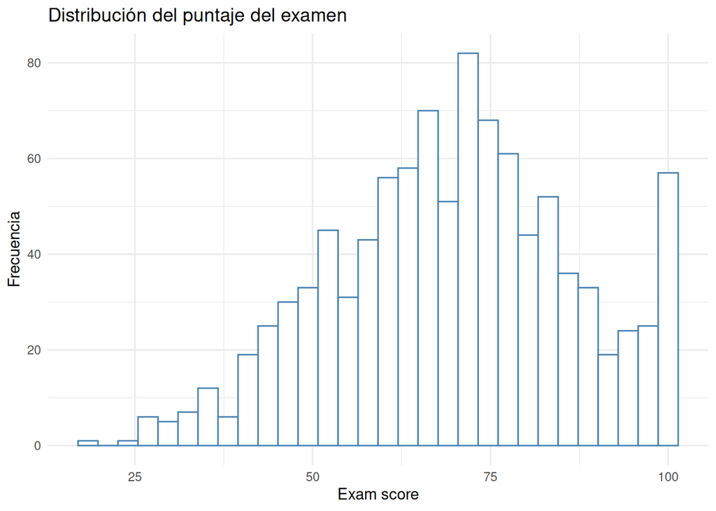

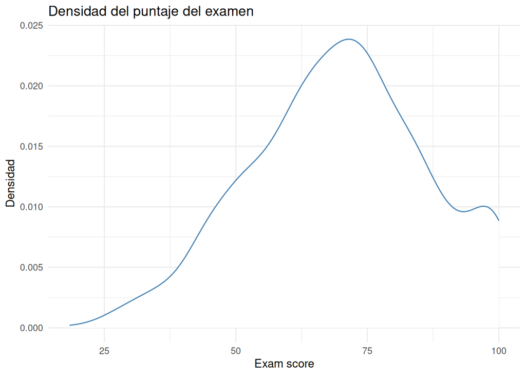

```
   Min. 1st Qu.  Median    Mean 3rd Qu.    Max.
  18.40   58.48   70.50   69.60   81.33  100.00
```

```
[1] 16.88856
```

```
[1]  18.4 100.0
```

### 1.1.1 Análisis de variables cuantitativas

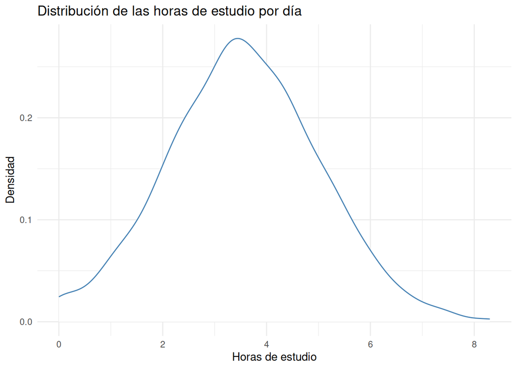

### 1.1.2 Análisis de variables categóricas

Dieta

| diet_quality | n |
| --- | --- |
| Poor | 185 |
| Fair | 437 |
| Good | 378 |

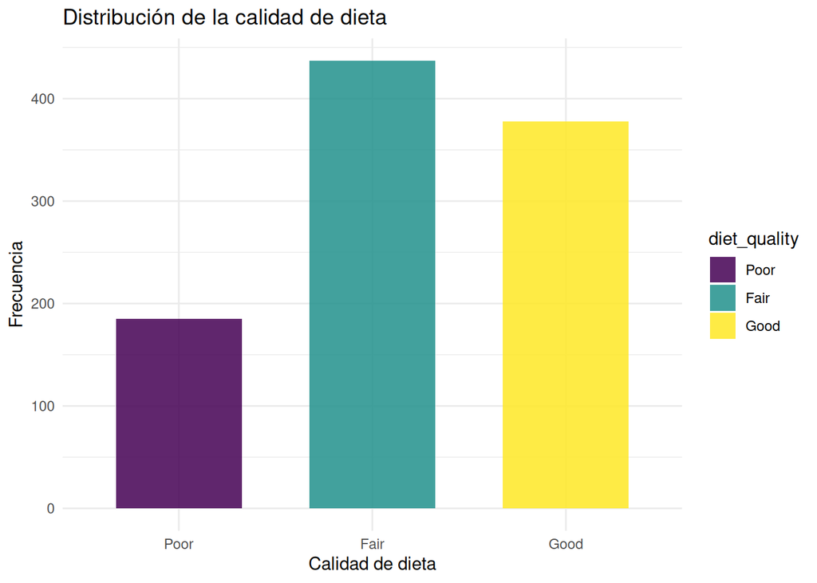

Calidad de Internet

| internet_quality | n |
| --- | --- |
| Poor | 162 |
| Average | 391 |
| Good | 447 |

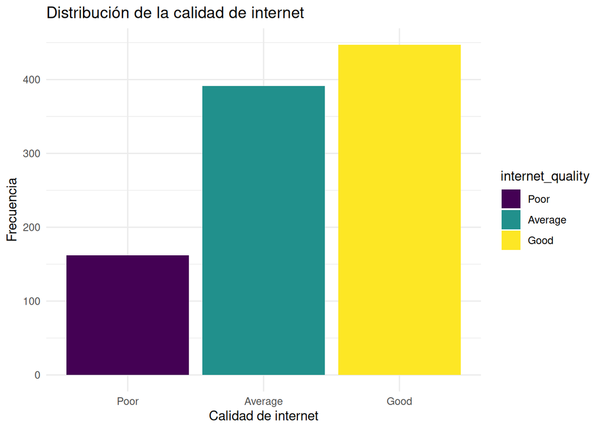

Género

```
.
Female   Male  Other
   481    477     42
```

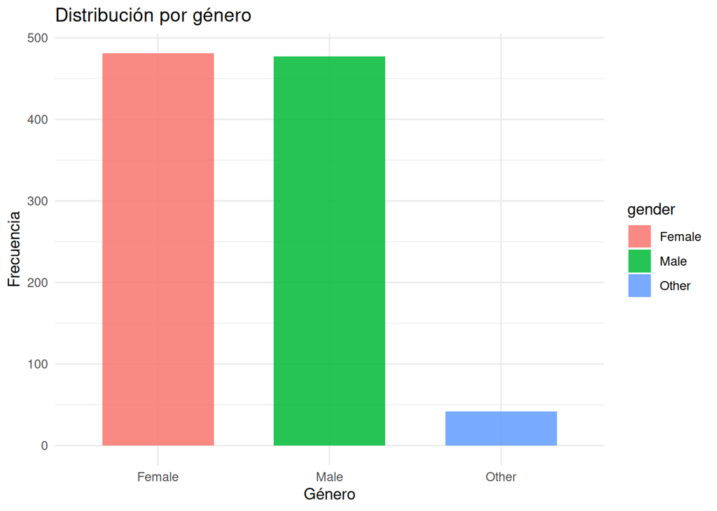

| parental_education_level | n |
| --- | --- |
| None | 91 |
| High School | 392 |
| Bachelor | 350 |
| Master | 167 |

Nivel educativo de los padres

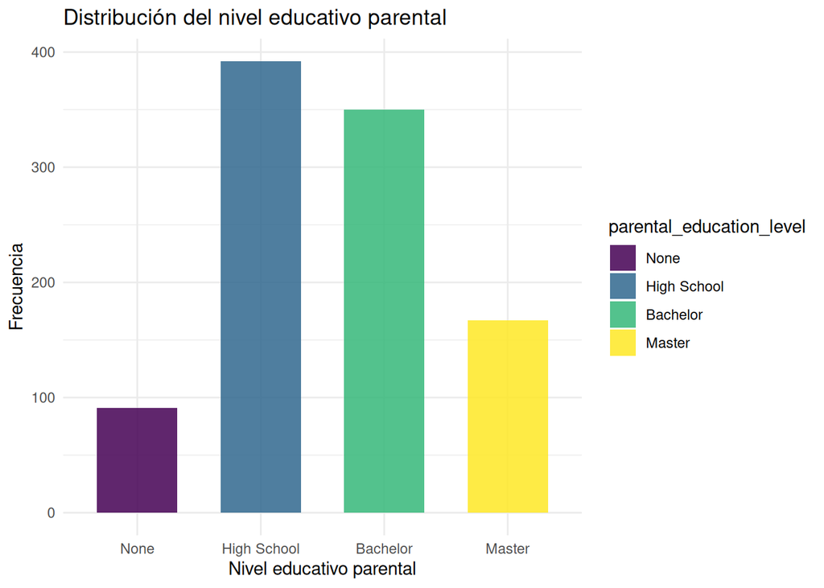

Este análisis descriptivo permite identificar la composición del dataset, la frecuencia de las categorías y la estructura general de las variables antes de evaluar su relación con el rendimiento académico.

#### 1.1.2.1 1. ¿Las horas de estudio diarias se relacionan con el puntaje del examen?

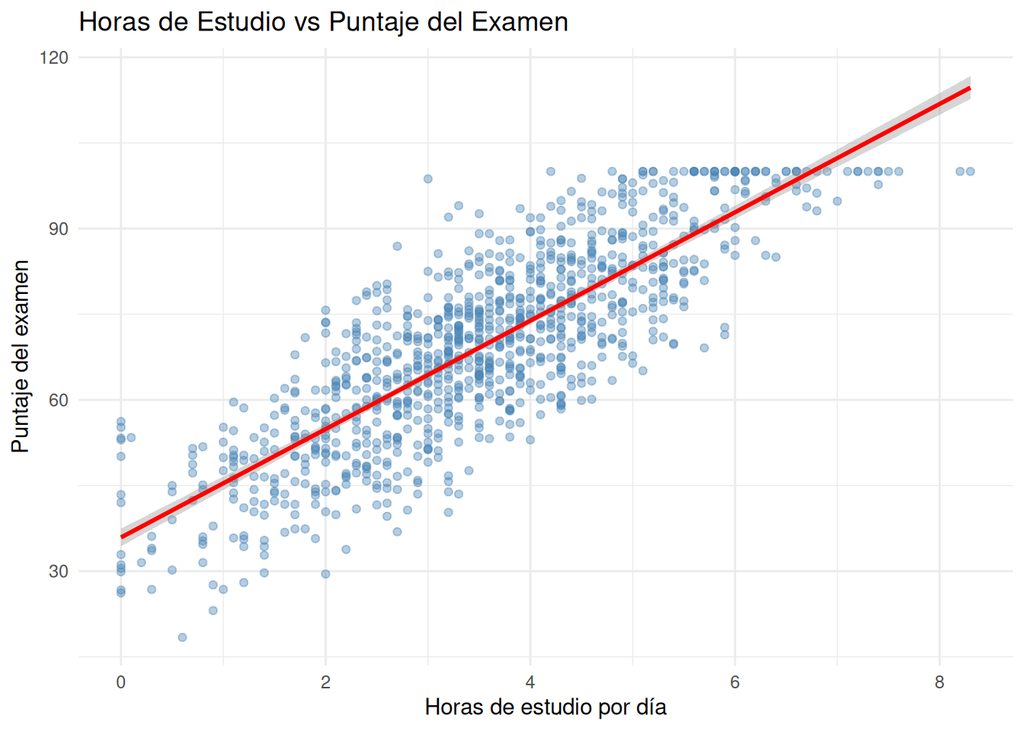

```
   Min. 1st Qu.  Median    Mean 3rd Qu.    Max.
   0.00    2.60    3.50    3.55    4.50    8.30
```

```
[1] 1.46889
```

```
[1] 0.0 8.3
```

```
    Pearson's product-moment correlation

data:  StudentsHabits$study_hours_per_day and StudentsHabits$exam_score
t = 46.191, df = 998, p-value < 2.2e-16
alternative hypothesis: true correlation is not equal to 0
95 percent confidence interval:
 0.8045968 0.8442130
sample estimates:
      cor
0.8254185
```

- *Qué muestra:*
  - Cada punto representa un estudiante. El eje X indica cuántas horas estudia por día y el eje Y su puntaje. La línea roja muestra la tendencia general. El resultado mostró una correlación positiva fuerte (r = 0.825) y estadísticamente significativa (p-value < 0.001), lo que indica que existe una relación directa entre ambas variables.Esto implica que a mayor cantidad de horas de estudio, mayor es el rendimiento académico, validando la hipótesis planteada y la tendencia observada en el gráfico.
- *Conclusión:*
  - Existe una *relación positiva*: a más horas de estudio, mayor puntaje. Es probablemente la variable con impacto más directo y visible en el rendimiento.

#### 1.1.2.2 2. ¿El tiempo en redes sociales afecta negativamente el rendimiento?

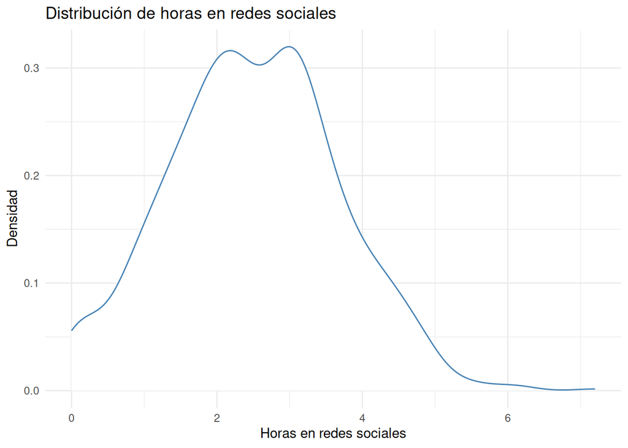

```
   Min. 1st Qu.  Median    Mean 3rd Qu.    Max.
  0.000   1.700   2.500   2.506   3.300   7.200
```

```
[1] 1.172422
```

```
[1] 0.0 7.2
```

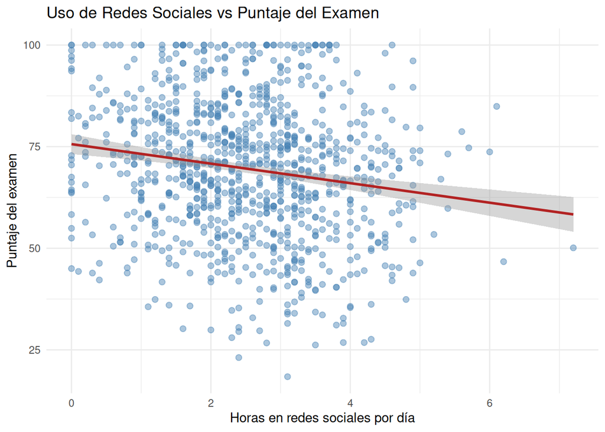

```
Call:
lm(formula = exam_score ~ social_media_hours, data = StudentsHabits)

Residuals:
    Min      1Q  Median      3Q     Max
-49.774 -11.065   0.367  11.341  35.429

Coefficients:
                   Estimate Std. Error t value Pr(>|t|)
(Intercept)         75.6191     1.2436  60.808  < 2e-16 ***
social_media_hours  -2.4018     0.4496  -5.342 1.14e-07 ***
---
Signif. codes:  0 '***' 0.001 '**' 0.01 '*' 0.05 '.' 0.1 ' ' 1

Residual standard error: 16.66 on 998 degrees of freedom
Multiple R-squared:  0.0278,    Adjusted R-squared:  0.02683
F-statistic: 28.54 on 1 and 998 DF,  p-value: 1.138e-07
```

- *Qué muestra:*
  - Cada punto representa un estudiante, ubicado según sus horas en redes sociales y su puntaje. La línea roja muestra la tendencia lineal general.
- *Conclusión:*
  - Se observa una tendencia negativa entre el tiempo dedicado a redes sociales y el rendimiento académico. A medida que aumentan las horas en redes sociales, el puntaje del examen tiende a disminuir.

[output not shown]

Min. 1st Qu. Median Mean 3rd Qu. Max. 3.20 5.60 6.50 6.47 7.30 10.00

[output not shown]

[1] 1.226377

[output not shown]

[1] 3.2 10.0

[output not shown]

Call: lm(formula = exam_score ~ sleep_hours, data = StudentsHabits)

Residuals: Min 1Q Median 3Q Max -49.073 -10.791 0.265 11.472 34.370

Residual standard error: 16.77 on 998 degrees of freedom Multiple R-squared: 0.01481, Adjusted R-squared: 0.01382 F-statistic: 15 on 1 and 998 DF, p-value: 0.0001146

[output not shown]

Min. 1st Qu. Median Mean 3rd Qu. Max. 1.000 3.000 5.000 5.438 8.000 10.000

[output not shown]

[1] 2.847501

[output not shown]

[1] 1 10

[output not shown]

Call: lm(formula = exam_score ~ mental_health_rating, data = StudentsHabits)

Residuals: Min 1Q Median 3Q Max -48.459 -10.291 0.341 11.042 37.862

Residual standard error: 16 on 998 degrees of freedom Multiple R-squared: 0.1034, Adjusted R-squared: 0.1025 F-statistic: 115.1 on 1 and 998 DF, p-value: < 2.2e-16

[output not shown]

```
Spearman's rank correlation rho
```

data: StudentsHabits$mental_health_rating and StudentsHabits$exam_score S = 112772581, p-value < 2.2e-16 alternative hypothesis: true rho is not equal to 0 sample estimates: rho 0.3233638

[output not shown]

Call: lm(formula = exam_score ~ exercise_frequency * diet_quality, data = StudentsHabits)

Residuals: Min 1Q Median 3Q Max -48.80 -11.16 0.62 11.81 35.28

Residual standard error: 16.67 on 994 degrees of freedom Multiple R-squared: 0.03065, Adjusted R-squared: 0.02577 F-statistic: 6.286 on 5 and 994 DF, p-value: 9.41e-06

[output not shown]

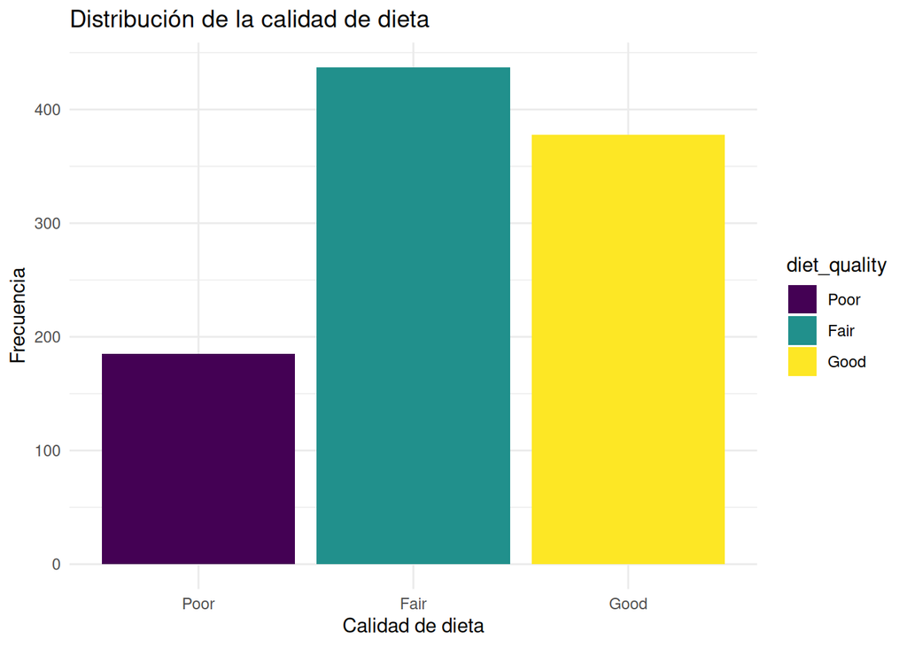

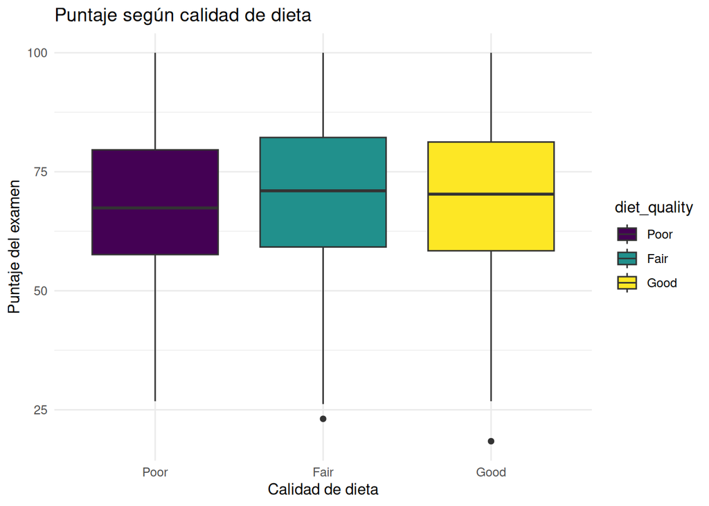

#### 1.1.2.3 6. ¿Los estudiantes con trabajo a tiempo parcial rinden menos?

```
    Welch Two Sample t-test

data:  con_trabajo and sin_trabajo
t = -0.8523, df = 346.73, p-value = 0.3946
alternative hypothesis: true difference in means is not equal to 0
95 percent confidence interval:
 -3.616297  1.429687
sample estimates:
mean of x mean of y
 68.74326  69.83656
```

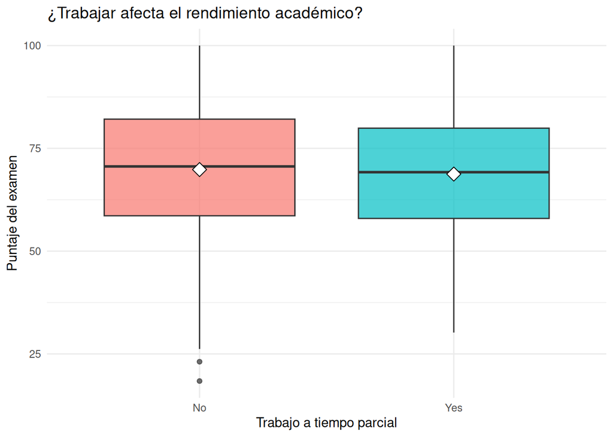

```
    Welch Two Sample t-test

data:  con_trabajo and sin_trabajo
t = -0.8523, df = 346.73, p-value = 0.3946
alternative hypothesis: true difference in means is not equal to 0
95 percent confidence interval:
 -3.616297  1.429687
sample estimates:
mean of x mean of y
 68.74326  69.83656
```

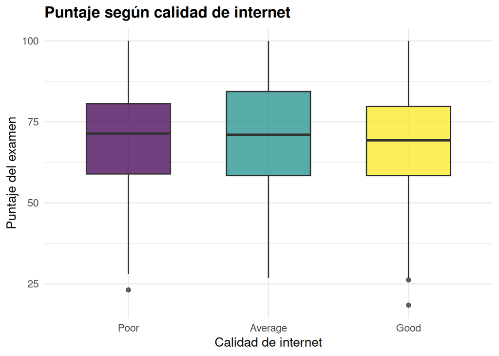

#### 1.1.2.4 Tabla del nivel educativo de los padres

Nivel educativo de los padres

| Nivel Educativo | Numero |
| --- | --- |
| None | 91 |
| High School | 392 |
| Bachelor | 350 |
| Master | 167 |

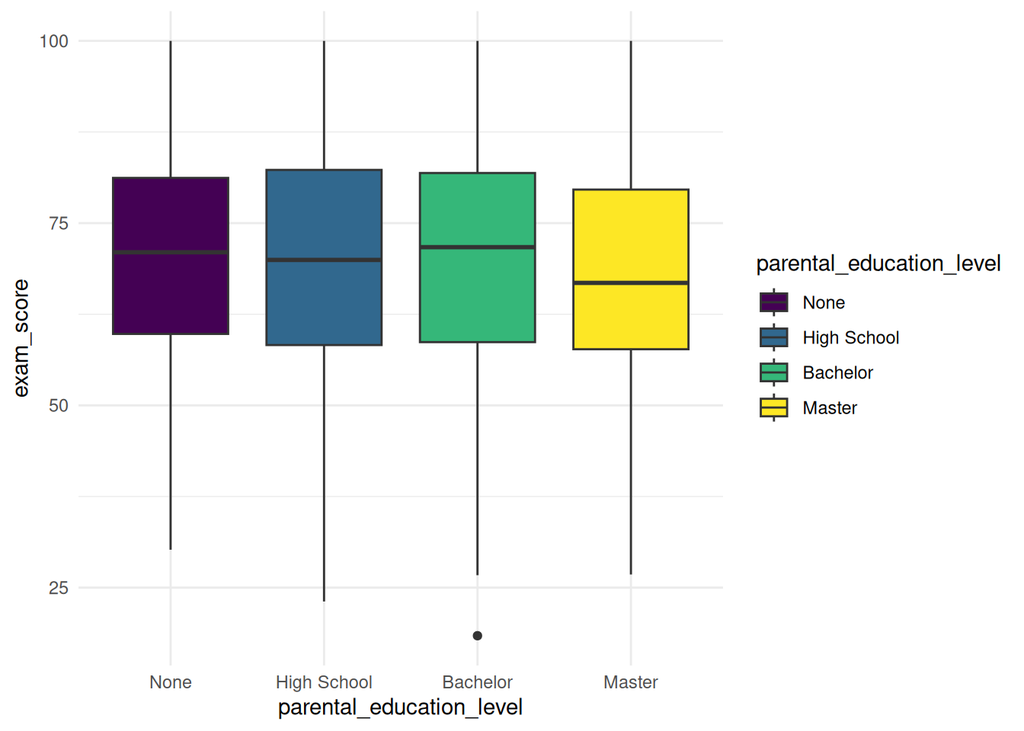

#### 1.1.2.5 Distribución del género

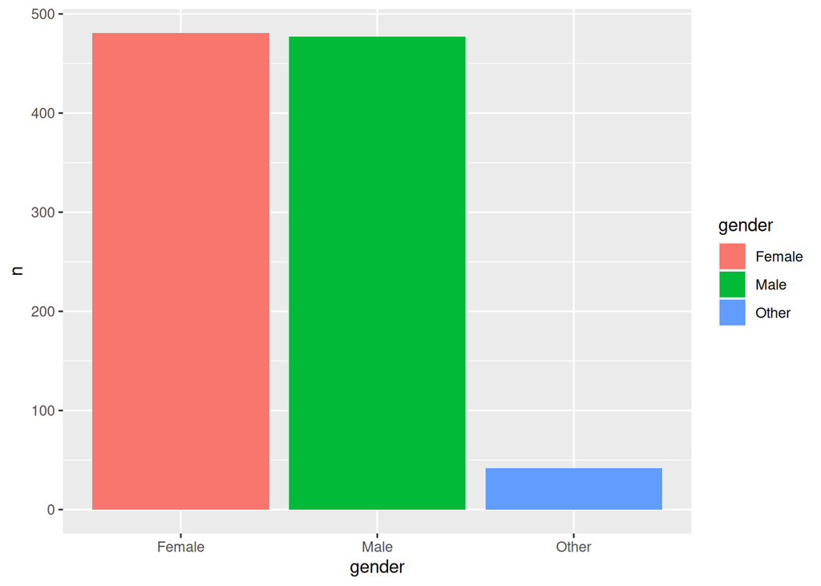

Distribución del género

## 1.2 Análisis complementarios

### 1.2.1 ¿El nivel educativo de los padres influye en el puntaje?

Para observar si el nivel educativo parental se relaciona con el rendimiento académico, se analiza la distribución del `exam_score` según cada categoría de `parental_education_level`.

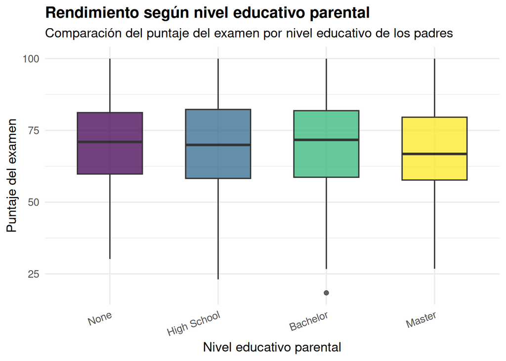

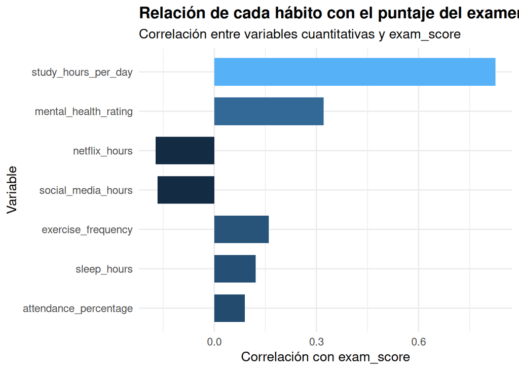

Ranking de variables según su correlación con el rendimiento académico

| Variable | Correlación con exam_score |
| --- | --- |
| study_hours_per_day | 0.8254185 |
| mental_health_rating | 0.3215229 |
| netflix_hours | -0.1717792 |
| social_media_hours | -0.1667329 |
| exercise_frequency | 0.1601075 |
| sleep_hours | 0.1216829 |
| attendance_percentage | 0.0898356 |

### 1.2.2 Conclusión

El análisis evidencia que no todos los hábitos impactan de la misma manera en el rendimiento académico. En particular, las horas de estudio presentan la relación positiva más fuerte con el puntaje del examen, consolidándose como el factor más determinante. En contraste, variables como el uso de redes sociales y el consumo de Netflix muestran asociaciones negativas, aunque de menor magnitud.

## 1.3 ¿Cómo es el estudiante con alto y bajo puntaje?

[figure not shown]

El análisis comparativo entre estudiantes de alto y bajo rendimiento permite identificar diferencias claras en sus hábitos. Los estudiantes con mejores puntajes presentan, en promedio, más horas de estudio y mayores niveles de asistencia, lo que refuerza la idea de que el compromiso académico es un factor central en el rendimiento.

Por el contrario, los estudiantes de bajo rendimiento tienden a dedicar más tiempo a actividades no académicas, como redes sociales y consumo de contenido (Netflix), lo que podría estar desplazando tiempo de estudio. Asimismo, se observan diferencias en variables como el sueño y la salud mental, que, aunque menos determinantes, contribuyen a configurar perfiles de desempeño distintos.

En conjunto, este análisis muestra que el rendimiento académico no responde a un único hábito, sino a un patrón de comportamiento donde el equilibrio entre estudio, descanso y uso del tiempo libre resulta clave.

## 1.4 Modelo de regresión lineal múltiple

Luego del análisis exploratorio y del estudio individual de las variables, se estima un modelo de regresión lineal múltiple con el objetivo de evaluar el efecto conjunto de los hábitos y características de los estudiantes sobre el rendimiento académico.

```
Call:
lm(formula = exam_score ~ study_hours_per_day + social_media_hours +
    sleep_hours + attendance_percentage + mental_health_rating +
    exercise_frequency + netflix_hours + diet_quality + part_time_job +
    parental_education_level + internet_quality + extracurricular_participation +
    gender, data = StudentsHabits)

Residuals:
     Min       1Q   Median       3Q      Max
-22.1957  -3.4768   0.1043   3.4683  15.5546

Coefficients:
                                 Estimate Std. Error t value Pr(>|t|)
(Intercept)                       6.10232    1.94115   3.144  0.00172 **
study_hours_per_day               9.57441    0.11571  82.742  < 2e-16 ***
social_media_hours               -2.60199    0.14481 -17.968  < 2e-16 ***
sleep_hours                       1.99148    0.13832  14.397  < 2e-16 ***
attendance_percentage             0.14349    0.01819   7.890 8.07e-15 ***
mental_health_rating              1.94461    0.05994  32.442  < 2e-16 ***
exercise_frequency                1.45013    0.08393  17.278  < 2e-16 ***
netflix_hours                    -2.28157    0.15769 -14.469  < 2e-16 ***
diet_quality.L                   -0.29085    0.34136  -0.852  0.39440
diet_quality.Q                   -0.38974    0.28844  -1.351  0.17695
part_time_jobYes                  0.21177    0.41388   0.512  0.60900
parental_education_level.L        0.23293    0.47850   0.487  0.62652
parental_education_level.Q       -0.47773    0.40232  -1.187  0.23534
parental_education_level.C       -0.03932    0.30850  -0.127  0.89861
internet_quality.L               -0.27605    0.34915  -0.791  0.42935
internet_quality.Q               -0.22877    0.29966  -0.763  0.44539
extracurricular_participationYes -0.01367    0.36407  -0.038  0.97006
genderMale                        0.14449    0.34772   0.416  0.67784
genderOther                       0.78978    0.86498   0.913  0.36144
---
Signif. codes:  0 '***' 0.001 '**' 0.01 '*' 0.05 '.' 0.1 ' ' 1

Residual standard error: 5.34 on 981 degrees of freedom
Multiple R-squared:  0.9018,    Adjusted R-squared:    0.9
F-statistic: 500.7 on 18 and 981 DF,  p-value: < 2.2e-16
```

## 1.5 Modelo con interacciones

```
Call:
lm(formula = exam_score ~ study_hours_per_day * sleep_hours +
    study_hours_per_day * mental_health_rating + social_media_hours *
    sleep_hours + diet_quality + parental_education_level, data = StudentsHabits)

Residuals:
     Min       1Q   Median       3Q      Max
-22.5526  -4.5672   0.0551   4.5450  18.5950

Coefficients:
                                         Estimate Std. Error t value Pr(>|t|)
(Intercept)                              11.94349    3.97678   3.003  0.00274
study_hours_per_day                      10.26740    0.84954  12.086  < 2e-16
sleep_hours                               2.74328    0.57474   4.773 2.09e-06
mental_health_rating                      2.28345    0.20428  11.178  < 2e-16
social_media_hours                       -1.13225    0.96951  -1.168  0.24314
diet_quality.L                           -0.41845    0.42653  -0.981  0.32681
diet_quality.Q                           -0.30142    0.36048  -0.836  0.40327
parental_education_level.L               -0.40213    0.59630  -0.674  0.50023
parental_education_level.Q               -0.50747    0.50331  -1.008  0.31357
parental_education_level.C               -0.31600    0.38462  -0.822  0.41150
study_hours_per_day:sleep_hours          -0.01930    0.11911  -0.162  0.87132
study_hours_per_day:mental_health_rating -0.10066    0.05319  -1.892  0.05872
sleep_hours:social_media_hours           -0.23472    0.14618  -1.606  0.10865

(Intercept)                              **
study_hours_per_day                      ***
sleep_hours                              ***
mental_health_rating                     ***
social_media_hours
diet_quality.L
diet_quality.Q
parental_education_level.L
parental_education_level.Q
parental_education_level.C
study_hours_per_day:sleep_hours
study_hours_per_day:mental_health_rating .
sleep_hours:social_media_hours
---
Signif. codes:  0 '***' 0.001 '**' 0.01 '*' 0.05 '.' 0.1 ' ' 1

Residual standard error: 6.693 on 987 degrees of freedom
Multiple R-squared:  0.8448,    Adjusted R-squared:  0.8429
F-statistic: 447.8 on 12 and 987 DF,  p-value: < 2.2e-16
```